# Introducing serrsBayes

Matt Moores

2021-06-28

The R package **serrsBayes** uses a sequential Monte Carlo (SMC) algorithm (Del Moral, Doucet, and Jasra 2006) to separate an observed spectrum into 3 components: the peaks $s_i(\tilde\nu)$; baseline $\xi_i(\tilde\nu)$; and additive white noise $\epsilon_{i,j} \sim \mathcal{N}(0, \sigma^2_\epsilon)$:
$$\mathbf{y}_i = \xi_i(\tilde\nu) + s_i(\tilde\nu) + \boldsymbol\epsilon_i$$
This is a type of *functional data analysis* (Ramsay, Hooker, and Graves 2009), since the discretised spectrum $\mathbf{y}_i$ is represented using latent (unobserved), continuous functions. The background fluorescence $\xi_i(\tilde\nu)$ is estimated using a penalised B-spline (Wood 2017), while the peaks can be modelled as Gaussian, Lorentzian, or pseudo-Voigt functions.

The Voigt function is a *convolution* of a Gaussian and a Lorentzian: $f_V(\nu_j) = (f_G * f_L)(\nu_j)$. It has an additional parameter $\eta_p$ that equals 0 for pure Gaussian and 1 for Lorentzian:
$$s_i(\nu_j) = \sum_{p=1}^P A_{i,p} f_V(\nu_j ; \ell_p, \varphi_p, \eta_p)$$
where $A_{i,p}$ is the *amplitude* of peak $p$; $\ell_p$ is the peak *location*; and $\varphi_p$ is the *broadening*. The horizontal axis of a Raman spectrum is measured in *wavenumbers* $\nu_j \in \Delta\tilde\nu$, with units of inverse centimetres (cm$^{-1}$). The vertical axis is measured in arbitrary units (a.u.), since the *intensity* of the Raman signal depends on the properties of the spectrometer. This functional model is explained further in our paper, Moores et al. (2016).

## Data

This example of surface-enhanced Raman spectroscopy (SERS) was originally published by Gracie et al. (2016):

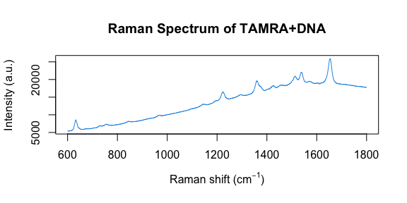

```r
library(serrsBayes)
data("lsTamra", package = "serrsBayes")
wavenumbers <- lsTamra$wavenumbers
spectra <- lsTamra$spectra
plot(wavenumbers, spectra[1,], type='l', col=4, main="Raman Spectrum of TAMRA+DNA",
     xlab=expression(paste("Raman shift (cm"^{-1}, ")")), ylab="Intensity (a.u.)")
```

```r
nWL <- length(wavenumbers)
```

## Priors

We will use the same priors that were described in the paper (Moores et al. 2016), including the TD-DFT peak locations from Watanabe et al. (2005):

```r
peakLocations <- c(615, 631, 664, 673, 702, 705, 771, 819, 895, 923, 1014,
                   1047, 1049, 1084, 1125, 1175, 1192, 1273, 1291, 1307, 1351, 1388, 1390,
                   1419, 1458, 1505, 1530, 1577, 1601, 1615, 1652, 1716)
nPK <- length(peakLocations)
priors <- list(loc.mu=peakLocations, loc.sd=rep(25,nPK), scaG.mu=log(10) - (0.34^2)/2,
               scaG.sd=0.34, scaL.mu=log(10) - (0.4^2)/2, scaL.sd=0.4, noise.nu=5, noise.sd=20,
               bl.smooth=1, bl.knots=121, beta.exp=80)
```

## Computation

Now we run the SMC algorithm to fit the model:

```r
data("result", package = "serrsBayes")
if(!exists("result")) {
  t1 <- Sys.time()
  result <- fitVoigtPeaksSMC(wavenumbers, spectra, priors, mcSteps=50, minPart = 7900, npart = 8000)
  result$time <- Sys.time() - t1
  save(result, file="Figure 2/result.rda")
}
```

```r
print(paste(format(result$time,digits=4)," for",length(result$ess),"SMC iterations."))
```

```
#> [1] "3.553 hours  for 254 SMC iterations."
```

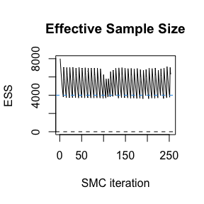

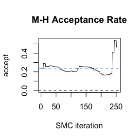

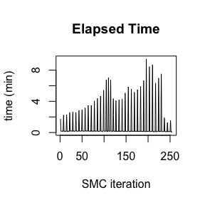

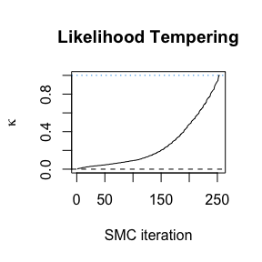

```r
plot.ts(result$ess, ylab="ESS", main="Effective Sample Size",
        xlab="SMC iteration", ylim=c(0,max(result$ess)))
abline(h=max(result$ess)/2, col=4, lty=2)
abline(h=0,lty=2)
plot.ts(result$accept, ylab="accept", main="M-H Acceptance Rate",
        xlab="SMC iteration", ylim=c(0,max(result$accept)))
abline(h=0.234, col=4, lty=2)
abline(h=0,lty=2)
plot.ts(result$times/60, ylab="time (min)", main="Elapsed Time", xlab="SMC iteration")
plot.ts(result$kappa, ylab=expression(kappa), main="Likelihood Tempering",
        xlab="SMC iteration")
abline(h=0,lty=2)
abline(h=1,lty=3,col=4)
```

## Posterior Inference

A subsample of particles can be used to plot the posterior distribution of the baseline and peaks:

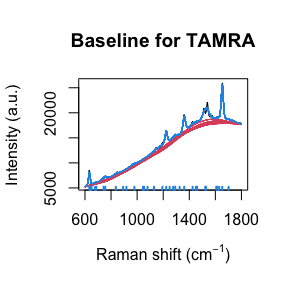

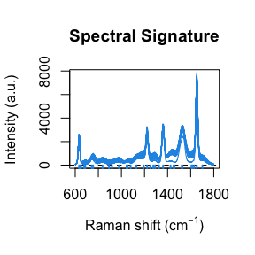

```r
samp.idx <- sample.int(length(result$weights), 50, prob=result$weights)
samp.mat <- resid.mat <- matrix(0,nrow=length(samp.idx), ncol=nWL)
samp.sigi <- samp.lambda <- numeric(length=nrow(samp.mat))
samp.loc <- colMeans(result$location)
spectra <- as.matrix(spectra)
plot(wavenumbers, spectra[1,], type='l', xlab=expression(paste("Raman shift (cm"^{-1}, ")")), ylab="Intensity (a.u.)")
for (pt in 1:length(samp.idx)) {
  k <- samp.idx[pt]
  samp.mat[pt,] <- mixedVoigt(result$location[k,], result$scale_G[k,],
                              result$scale_L[k,], result$beta[k,], wavenumbers)
  samp.sigi[pt] <- result$sigma[k]
  samp.lambda[pt] <- result$lambda[k]

  Obsi <- spectra[1,] - samp.mat[pt,]
  g0_Cal <- length(Obsi) * samp.lambda[pt] * result$priors$bl.precision
  gi_Cal <- crossprod(result$priors$bl.basis) + g0_Cal
  mi_Cal <- as.vector(solve(gi_Cal, crossprod(result$priors$bl.basis, Obsi)))

  bl.est <- result$priors$bl.basis %*% mi_Cal # smoothed residuals = estimated basline
  lines(wavenumbers, bl.est, col=2)
  lines(wavenumbers, bl.est + samp.mat[pt,], col=4)
  resid.mat[pt,] <- Obsi - bl.est[,1]
}
title(main="Baseline for TAMRA")
rug(samp.loc, col=4,lwd=2)

plot(range(wavenumbers), range(samp.mat), type='n', xlab=expression(paste("Raman shift (cm"^{-1}, ")")), ylab="Intensity (a.u.)")
abline(h=0,lty=2)
for (pt in 1:length(samp.idx)) {
  lines(wavenumbers, samp.mat[pt,], col=4)
}
title(main="Spectral Signature")
rug(samp.loc,col=4,lwd=2)
```

Notice that the uncertainty in the baseline is greatest where the peaks are bunched close together, which is exactly what we would expect. This is also reflected in uncertainty of the spectral signature.

We can compute the Voigt parameters and the full width at half maximum (FWHM) for each peak:

```r
result$voigt <- result$FWHM <- matrix(nrow=nrow(result$beta), ncol=ncol(result$beta))
for (k in 1:nrow(result$beta)) {
  result$voigt[k,] <- getVoigtParam(result$scale_G[k,], result$scale_L[k,])
  f_G <- result$scale_G[k,]
  f_L <- result$scale_L[k,]
  result$FWHM[k,] <- 0.5346*f_L + sqrt(0.2166*f_L^2 + f_G^2)
}
```

Finally, display the lower and upper 95% highest posterior density (HPD) intervals for the parameters of each peak:

95% highest posterior density intervals for pseudo-Voigt peaks

| Location (cm-1) | Amplitude | FWHM (cm-1) | Voigt |
| --- | --- | --- | --- |
| [ 633; 634] | [2333.5; 2549.2] | [ 8.8; 9.7] | [0.32; 0.40] |
| [ 637; 650] | [ 4.3; 28.2] | [24.6; 30.1] | [0.47; 0.69] |
| [ 643; 661] | [ 23.5; 80.4] | [28.8; 36.2] | [0.30; 0.38] |
| [ 665; 691] | [ 0.2; 1.0] | [21.2; 27.4] | [0.46; 0.57] |
| [ 677; 695] | [ 82.1; 273.8] | [25.0; 31.3] | [0.52; 0.71] |
| [ 736; 751] | [ 118.9; 243.6] | [33.7; 42.1] | [0.44; 0.59] |
| [ 752; 758] | [ 378.0; 747.3] | [30.6; 45.5] | [0.61; 0.77] |
| [ 833; 841] | [ 313.7; 513.2] | [34.4; 38.6] | [0.25; 0.34] |
| [ 881; 905] | [ 10.2; 21.1] | [20.4; 29.5] | [0.18; 0.27] |
| [ 902; 938] | [ 140.3; 338.2] | [43.1; 57.6] | [0.21; 0.33] |
| [ 968; 991] | [ 169.8; 475.4] | [25.5; 36.2] | [0.23; 0.34] |
| [1036; 1052] | [ 3.9; 18.6] | [19.2; 24.1] | [0.47; 0.70] |
| [1048; 1058] | [ 167.4; 310.7] | [34.7; 45.7] | [0.34; 0.49] |
| [1061; 1095] | [ 25.0; 62.3] | [32.1; 43.9] | [0.37; 0.61] |
| [1123; 1137] | [ 266.8; 547.0] | [23.8; 38.1] | [0.11; 0.18] |
| [1182; 1204] | [ 471.8; 899.2] | [54.4; 65.9] | [0.30; 0.42] |
| [1223; 1223] | [2184.5; 2367.0] | [11.8; 13.2] | [0.35; 0.44] |
| [1240; 1259] | [ 10.7; 76.6] | [18.0; 23.4] | [0.28; 0.42] |
| [1271; 1283] | [ 7.4; 45.8] | [28.5; 34.9] | [0.48; 0.61] |
| [1289; 1298] | [ 441.8; 834.0] | [27.8; 35.4] | [0.28; 0.43] |
| [1305; 1341] | [ 0.6; 1.8] | [26.3; 37.8] | [0.24; 0.40] |
| [1361; 1362] | [3022.3; 3191.4] | [14.4; 15.7] | [0.45; 0.50] |
| [1421; 1431] | [ 616.1; 931.1] | [39.0; 48.9] | [0.22; 0.30] |
| [1443; 1457] | [ 29.9; 112.8] | [24.6; 33.3] | [0.17; 0.25] |
| [1455; 1467] | [ 83.8; 528.4] | [28.2; 37.9] | [0.39; 0.51] |
| [1513; 1528] | [ 2.9; 118.6] | [22.8; 27.1] | [0.24; 0.36] |
| [1527; 1531] | [2795.0; 3249.2] | [33.2; 37.9] | [0.34; 0.49] |
| [1599; 1614] | [ 4.7; 26.7] | [26.2; 35.9] | [0.24; 0.38] |
| [1609; 1622] | [ 391.7; 835.6] | [31.2; 40.8] | [0.22; 0.31] |
| [1620; 1644] | [ 1.4; 3.5] | [47.7; 54.5] | [0.15; 0.20] |
| [1653; 1653] | [6735.3; 6930.2] | [10.8; 11.4] | [0.36; 0.41] |
| [1693; 1710] | [ 339.2; 684.2] | [40.8; 53.9] | [0.34; 0.45] |

# References

Del Moral, Pierre, Arnaud Doucet, and Ajay Jasra. 2006. “Sequential Monte Carlo Samplers.” *J. R. Stat. Soc. Ser. B* 68 (3): 411–36. https://doi.org/10.1111/j.1467-9868.2006.00553.x.

Gracie, K., M. Moores, W. E. Smith, Kerry Harding, M. Girolami, D. Graham, and K. Faulds. 2016. “Preferential Attachment of Specific Fluorescent Dyes and Dye Labelled DNA Sequences in a SERS Multiplex.” *Anal. Chem.* 88 (2): 1147–53. https://doi.org/10.1021/acs.analchem.5b02776.

Jacob, Pierre E., Lawrence M. Murray, and Sylvain Rubenthaler. 2015. “Path Storage in the Particle Filter.” *Stat. Comput.* 25 (2): 487–96. https://doi.org/10.1007/s11222-013-9445-x.

Lee, Anthony, and Nick Whiteley. 2015. “Variance Estimation in the Particle Filter.” *arXiv Preprint arXiv:1509.00394 [Stat.CO]*. https://arxiv.org/abs/1509.00394.

Moores, M., K. Gracie, J. Carson, K. Faulds, D. Graham, and M. Girolami. 2016. “Bayesian Modelling and Quantification of Raman Spectroscopy.” *arXiv Preprint arXiv:1604.07299 [Stat.AP]*. https://arxiv.org/abs/1604.07299.

Ramsay, Jim O., Giles Hooker, and Spencer Graves. 2009. *Functional Data Analysis with R and MATLAB*. Use r! New York: Springer. https://doi.org/10.1007/978-0-387-98185-7.

Watanabe, Hiroyuki, Norihiko Hayazawa, Yasushi Inouye, and Satoshi Kawata. 2005. “DFT Vibrational Calculations of Rhodamine 6g Adsorbed on Silver: Analysis of Tip-Enhanced Raman Spectroscopy.” *J. Phys. Chem. B* 109 (11): 5012–20. https://doi.org/10.1021/jp045771u.

Wood, Simon N. 2017. *Generalized Additive Models: An Introduction with r*. 2nd ed. Boca Raton, FL, USA: Chapman & Hall/CRC Press.